# Additional HVarPart sensitivity analysis

## Additional analysis and correction

During additional quality-control checks of the hierarchical variation partitioning results, we identified an error in our previous post-processing: negative adjusted contributions were not retained. This issue was identified by the authors rather than raised by the reviewers. We replaced the previous pathway with a single extractor that preserves HVarPart’s `Unique`, `Average.share`, `Individual`, `I.perc(%)`, and total adjusted $R^2$ values.

We compared three reporting profiles:

1. **Signed:** retain each unmodified individual contribution.
2. **Zero-truncated:** replace negative individual contributions with exactly zero and recompute the denominator from the truncated contributions.
3. **Exclude-negative:** exclude the complete model if either predictor has a negative individual contribution.

Within reporting group $g$, the untruncated signed hierarchical contribution of predictor $p$ is

$$A_{p,g} = \frac{\sum_m I_{p,m}}{\sum_m R^2_{\mathrm{adj},m}},$$

where $I_{p,m}$ is HVarPart’s unmodified individual contribution. Models are otherwise excluded only when required predictors are absent, the denominator is non-finite or non-positive, or an individual contribution is non-finite. Every exclusion is recorded in `Outputs/Tables/Diagnostics/HVarPart/hvarpart__model_audit.csv`.

A negative signed hierarchical contribution is an adjusted partitioning result. It is not evidence of a negative ecological effect.

## Results and presentation

For spatial SPD models, the zero-truncated and renormalised shares underlying the main balance figure are 75.6% for climate and 24.4% for human impact. The corresponding untruncated signed hierarchical contributions are 76.4% and 23.6%. Excluding complete models with any negative contribution gives 72.4% for climate.

Across all five analyses, climate remains larger than human impact under all three profiles: yes.

Because the profiles support the same overall interpretation, the main figures use zero-truncated and renormalised shares of positive hierarchical contribution. Figure 2 presents the human-minus-climate balance spatially, Figure 3 shows the human, climate, and spatial shares through time, and Figure 4 uses the human-minus-climate balance within its importance insets. Signed versions of Figures 2–4 are provided in the Supplementary Information, and the exclude-negative analysis is reported as an additional sensitivity profile.

Table 1: Model-level HVarPart eligibility audit. Counts are not duplicated across predictor rows.

| Analysis | Models | Eligible | Excluded | Neg. unique | Neg. individual |
| --- | --- | --- | --- | --- | --- |
| h2 spd | 31 | 31 | 0 | 1 | 0 |
| spatial events | 1262 | 257 | 1005 | 75 | 34 |
| spatial spd | 1262 | 1118 | 144 | 481 | 265 |
| temporal events | 85 | 76 | 9 | 13 | 10 |
| temporal spd | 70 | 69 | 1 | 14 | 6 |

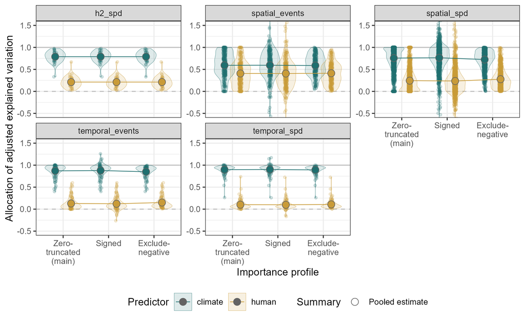

Figure 1: Zero-truncated and renormalised main-figure composition and two sensitivity profiles, calculated from the preserved fitted HVarPart results.

## Figure changes

Figure 2 now expresses the complementary zero-truncated human and climate shares as human minus climate importance. The bounded scale runs from -1 (climate impact) through 0 (equal importance) to 1 (human impact). For each continent, the figure combines the continent-wide distribution of record-level balances, pooled climate-zone balances, and a horizontal line for the pooled continental balance. Densities use a continuous climate-to-neutral-to-human colour scale; the climate-zone panels use the same scale as a pale background while their summary points retain categorical climate-zone colours. Maps and continental density panels do not use the background gradient. The supplementary counterpart reports the untruncated human-minus-climate hierarchical contribution difference with the same spatially filtered summaries.

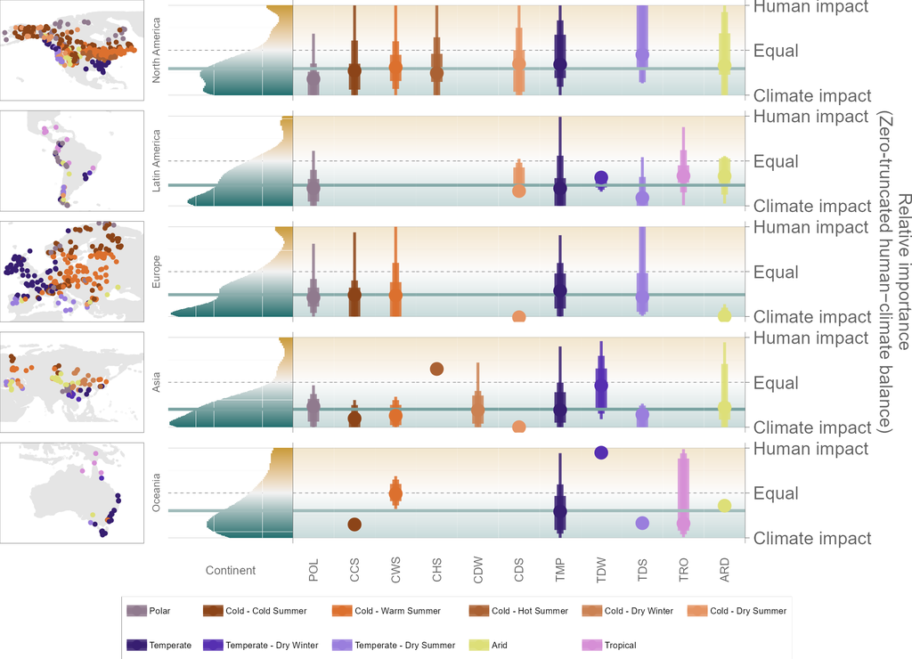

*Revised main manuscript Figure 2. Spatial balance between zero-truncated and renormalised human and climate shares.*

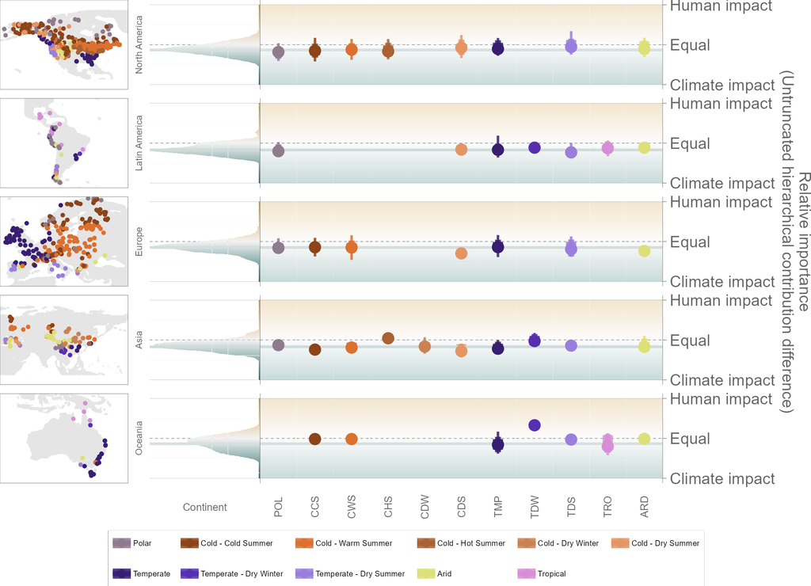

*Supplementary signed Figure 2. Untruncated human-minus-climate hierarchical contribution difference with time and space control.*

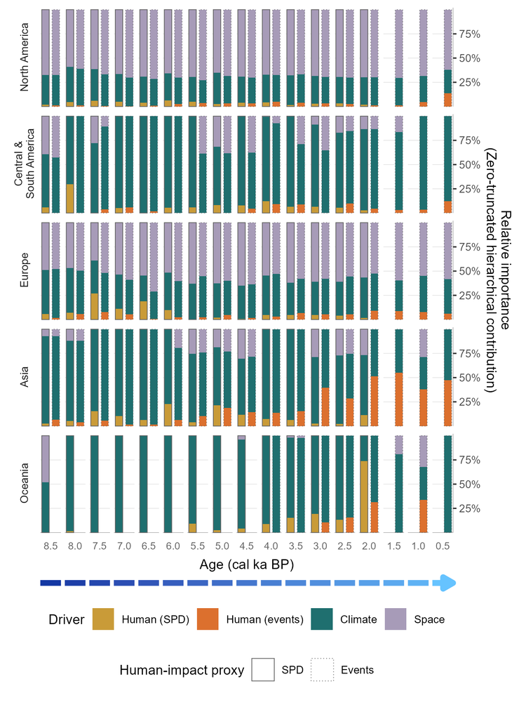

*Revised main manuscript Figure 3. Temporal composition of zero-truncated and renormalised human and climate shares.*

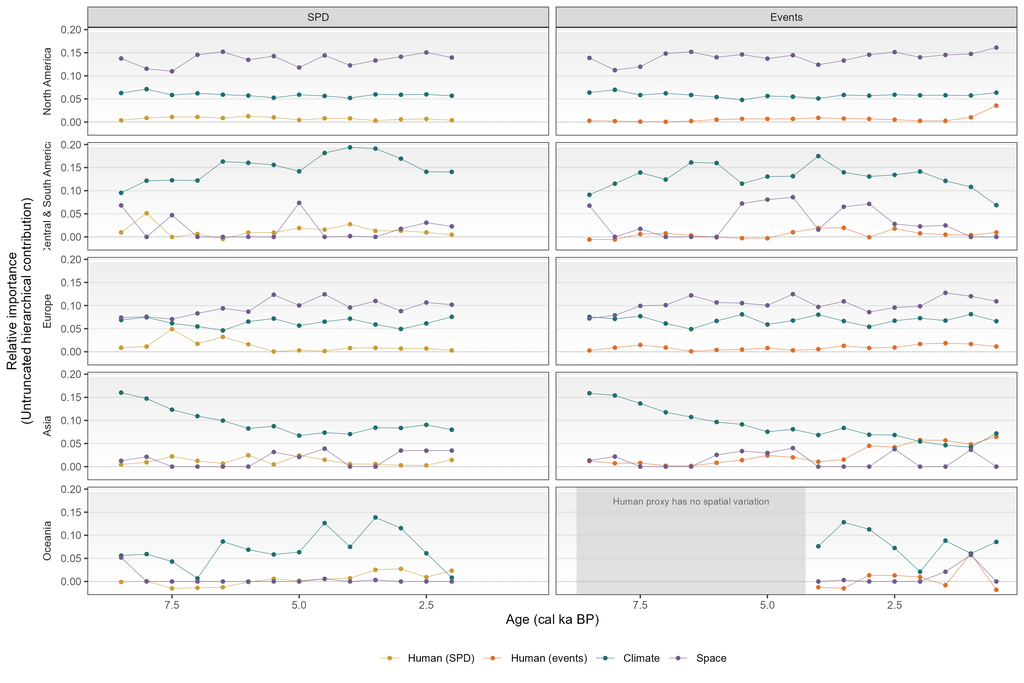

*Supplementary signed Figure 3. Untruncated signed climate and human hierarchical contributions through time.*

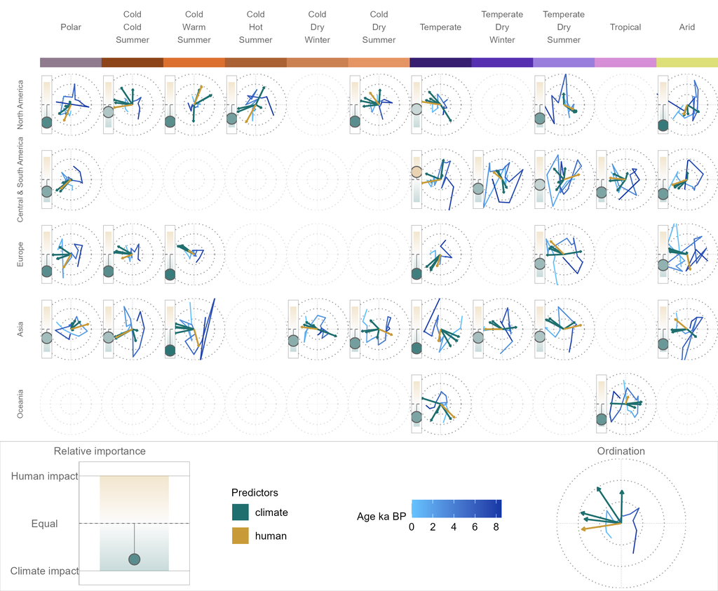

*Revised main manuscript Figure 4. Multidimensional community-change ordinations with balance lollipops for human and climate importance.*

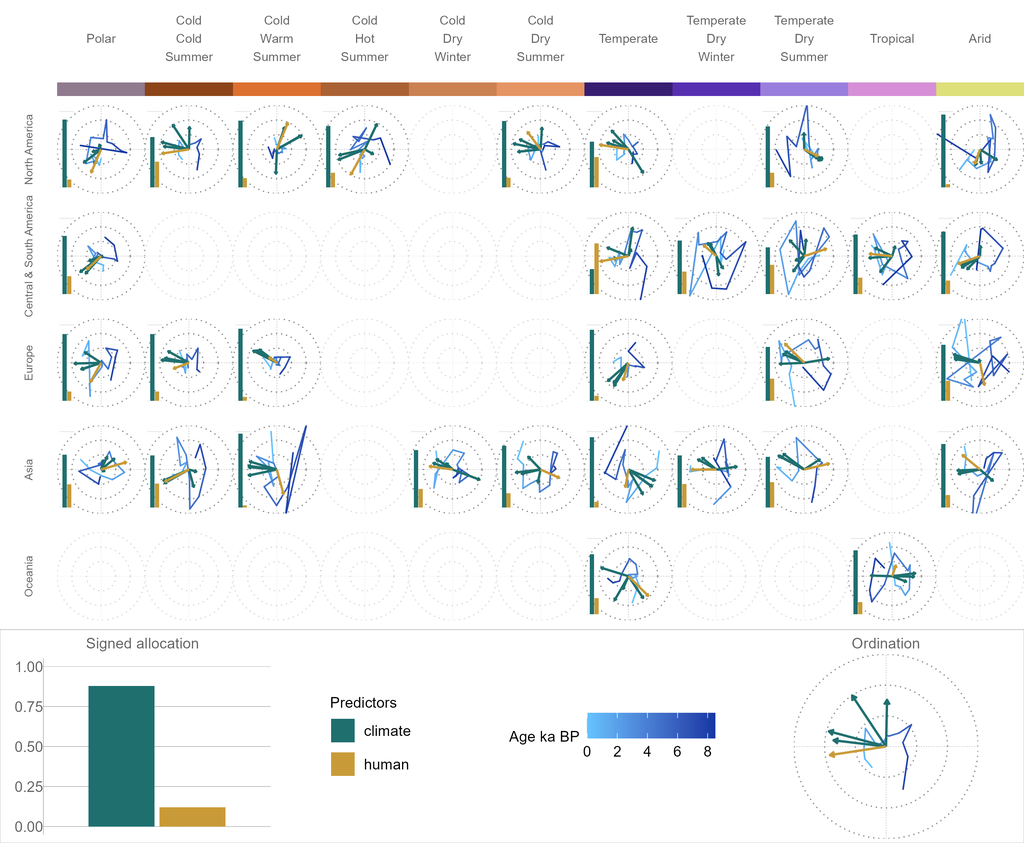

*Supplementary signed Figure 4. Multidimensional community-change ordinations with separate untruncated signed human and climate hierarchical contributions.*